# Network Summary Statistics

Load Network

```r
#statnet object
net3
```

```
 Network attributes:
  vertices = 5
  directed = TRUE
  hyper = FALSE
  loops = FALSE
  multiple = FALSE
  bipartite = FALSE
  total edges= 8
    missing edges= 0
    non-missing edges= 8

 Vertex attribute names:
    vertex.names

No edge attributes
```

#### Graph Density

```r
network.density(net3)
```

```
[1] 0.4
```

#### Reciprocity

percentage of relationships that are reciprocated (where there is at least one tie) or symmetry of the matrix (takes into consiredation nodes with no ties - 2 nodes with no ties considered symmetric)

```r
#measures what percentage of ties is reciprocated.
grecip(net3, measure = "dyadic.nonnull")
```

```
      Mut
0.3333333
```

```r
#measures the overall symmetry of the network taking into account nodes that are not connecte at all as well.
grecip(net3, measure = "edgewise")
```

```
Mut
0.5
```

#### Number of Components

A network of nodes that are not all connected with eachother is a network made up of **components** which are made up of a group of nodes that are all connected to each other but not connected to the nodes in other components.

For undirected graphs the concept is straight forward. In directed graphs, we can say that a component is strongly connected if, for all pairs of nodes in the component, there is a directed path connecting the nodes in both directions.

A component is weekly connected if the pairs have a semi-path between them.

```r
components(net3,connected="strong")
components(net3,connected="weak")
```

[output not shown]

#### Diameter

The graph diameter is a measure used to describe the magnitude of a network (along with size - n of edges - and order - n of nodes). This measures how compact the graph is, give its particular size and order.  
The diameter of a graph is the longest of the**geodesics** defined across all pairs of nodes in a network.  
A **geodesic** is the shortest of reaching one node from another node following its edges.  
We can measure the diameter only if the graph is connected

```r
#for directed graph
max(geodist(net3)$gdist)
```

```
[1] Inf
```

```r
#for a symmetrized verion of the directed graph - a undirected graph-
max(geodist(symmetrize(net3))$gdist)
```

```
[1] 3
```

#### Transitivity/Clustering Coeffient

Tendency of networks to form “triangles”. For example, A is friend of B, which is friend of C, which is friend of A. Transitivity is the proportion of triads in a network. When transitivity values are closer to 1, this indicates high tendancy toward transitivity of connections.

```r
gtrans(net3, mode = "weak")
```

```
[1] 0.5
```

#### Cliques

A clique is a subgroup of nodes in a network that are all undirectly connected to each other. A clique is a subgraph with density = 1.

```r
#find largest size of clique
clique.number(inet3)
```

```
At cliques.c:1087 :directionality of edges is ignored for directed graphs
```

```
[1] 3
```

```r
#identify cliques of size between 2 and 3
cliques(inet3, min = 2, max = 3)
```

```
At igraph_cliquer.c:56 :Edge directions are ignored for clique calculations
```

```
[[1]]
+ 2/5 vertices, from b40add6:
[1] 1 3

[[2]]
+ 2/5 vertices, from b40add6:
[1] 3 4

[[3]]
+ 2/5 vertices, from b40add6:
[1] 4 5

[[4]]
+ 2/5 vertices, from b40add6:
[1] 2 3

[[5]]
+ 3/5 vertices, from b40add6:
[1] 1 2 3

[[6]]
+ 3/5 vertices, from b40add6:
[1] 2 3 4

[[7]]
+ 2/5 vertices, from b40add6:
[1] 1 2

[[8]]
+ 2/5 vertices, from b40add6:
[1] 2 4
```

```r
#other useful commands
maximal.cliques(inet3)
```

```
At ./maximal_cliques_template.h:203 :Edge directions are ignored for maximal clique calculation
```

```
[[1]]
+ 2/5 vertices, from b40add6:
[1] 5 4

[[2]]
+ 3/5 vertices, from b40add6:
[1] 1 2 3

[[3]]
+ 3/5 vertices, from b40add6:
[1] 2 4 3
```

```r
largest.cliques(inet3)
```

```
At cliques.c:1087 :directionality of edges is ignored for directed graphs
```

```
[[1]]
+ 3/5 vertices, from b40add6:
[1] 2 3 4

[[2]]
+ 3/5 vertices, from b40add6:
[1] 2 3 1
```

#### K-Cores

A k-core is a group of nodes where each of them is connected to at least k other nodes.

```r
graph.coreness(inet3)
```

```
[1] 3 3 3 3 1
```

#### Basic Community Detection

A community is a group a nodes that is internally cohesive but weakly connected outside the group.  
Modularity is one way of measuring how well a graphs clusters based on an observed categorical node characteristic. Modularity ranges from -0.5 to 1. Larger values stronger clustering due to grouping variable.

```r
net3%v%"gender"
```

```
[1] NA NA NA NA NA
```

```r
gender<-c("M","F","M","M","F")
modularity(asIgraph(net3), as.factor(gender))
```

```
Modularity is implemented for undirected graphs only.
```

```
[1] -0.1953125
```

Example of community detection with the doctors dataset

|  | V1 | V2 | V3 | V4 | V5 | V6 | V7 | V8 | V9 | V10 | V11 | V12 | V13 | V14 | V15 | V16 | V17 | V18 | V19 | V20 | V21 | V22 | V23 | V24 | V25 | V26 | V27 | V28 | V29 | … |
| --- | --- | --- | --- | --- | --- | --- | --- | --- | --- | --- | --- | --- | --- | --- | --- | --- | --- | --- | --- | --- | --- | --- | --- | --- | --- | --- | --- | --- | --- | --- |
| 1 | 0 | 0 | 0 | 0 | 0 | 0 | 0 | 1 | 0 | 0 | 0 | 0 | 0 | 0 | 0 | 0 | 0 | 0 | 0 | 0 | 0 | 0 | 0 | 0 | 0 | 0 | 0 | 0 | 0 | … |
| 2 | 0 | 0 | 0 | 0 | 0 | 0 | 0 | 0 | 0 | 0 | 1 | 0 | 0 | 0 | 0 | 0 | 0 | 0 | 0 | 0 | 0 | 0 | 0 | 0 | 0 | 0 | 0 | 0 | 0 | … |
| 3 | 0 | 0 | 0 | 0 | 0 | 0 | 0 | 0 | 1 | 0 | 0 | 0 | 0 | 1 | 0 | 1 | 0 | 0 | 0 | 1 | 0 | 0 | 0 | 0 | 0 | 0 | 0 | 0 | 1 | … |
| 4 | 0 | 0 | 0 | 0 | 0 | 0 | 1 | 0 | 0 | 0 | 0 | 0 | 0 | 0 | 0 | 0 | 0 | 0 | 0 | 0 | 0 | 0 | 0 | 0 | 0 | 0 | 0 | 0 | 0 | … |
| 5 | 0 | 0 | 0 | 0 | 0 | 0 | 0 | 0 | 0 | 1 | 0 | 1 | 0 | 0 | 1 | 0 | 0 | 0 | 0 | 0 | 0 | 0 | 0 | 0 | 0 | 0 | 0 | 0 | 0 | … |
| 6 | 0 | 0 | 0 | 0 | 0 | 0 | 0 | 0 | 0 | 0 | 0 | 0 | 0 | 0 | 0 | 0 | 0 | 0 | 0 | 0 | 0 | 0 | 0 | 0 | 0 | 0 | 0 | 0 | 1 | … |

```r
anti.inet<-graph_from_adjacency_matrix(as.matrix(data))
cw<-cluster_walktrap(anti.inet)
table(membership(cw))
```

```
 1  2  3  4  5  6  7  8  9 10 11 12 13 14
48 24 27  3 62 49  8  6 14  1  1  1  1  1
```

```r
modularity(cw)
```

```
[1] 0.667931
```

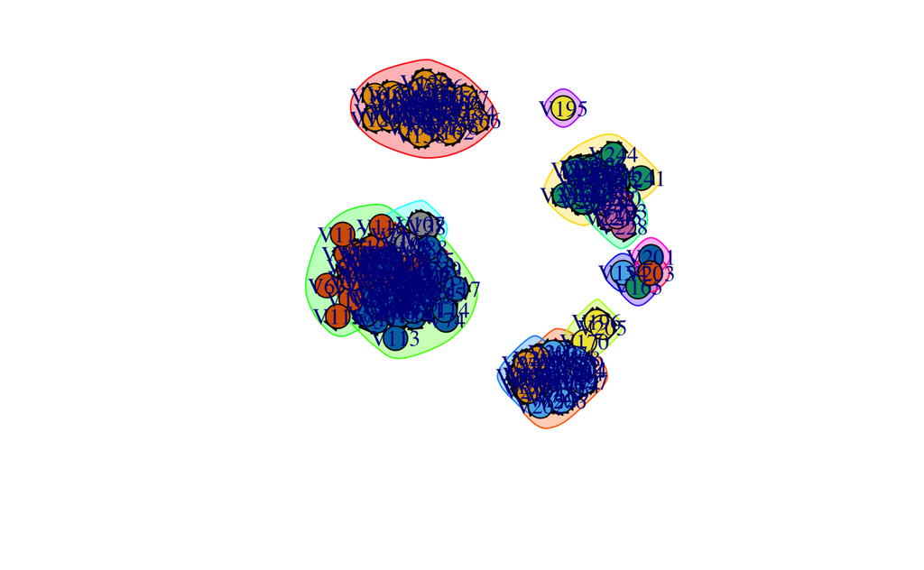

```r
plot(cw, anti.inet)
```

```r
table(membership(cb))
```

```
  1   2   3   4   5   6   7   8   9
117  48   1   1  41   1   1   1  35
```

```r
modularity(cb)
```

```
[1] 0.6625227
```

```r
chisq.test(table(membership(cw), membership(cb)))
```

```
Chi-squared approximation may be incorrect
```

```
    Pearson's Chi-squared test

data:  table(membership(cw), membership(cb))
X-squared = 1968, df = 104, p-value < 2.2e-16
```

```r
compare(cw, cb, method = "adjusted.rand")
```

```
[1] 0.6104353
```